# Mini Project

Nawal Krishna S

2025-11-10

## 1.Introduction

This project examines global disaster patterns over the period 2000–2025, based on datasets extracted from the EM-DAT International Disaster Database. The goal is twofold:

To identify global disaster hotspots using geospatial coordinates.

To compute a country-level Vulnerability Index combining human and economic impact indicators.

## 2.Loading Libraries

we load all the R packages necessary for data wrangling, visualization, mapping, missing data exploration, and reading data from Google Drive.

```r
library(readr)
library(dplyr)
library(tidyr)
library(stringr)
library(forcats)
library(lubridate)
```

```r
library(ggplot2)
library(viridis)
library(naniar)
library(visdat)
library(simputation)
library(leaflet)
library(leaflet.extras)
library(leaflet.providers)

library(googledrive)
```

## 3.Accessing and Downloading Data from Google Drive

The EM-DAT regional CSV files were stored in Google Drive. We authenticate access via the googledrive package and download the files directly into the working environment.

```r
drive_deauth()
drive_auth()
```

[output not shown]

[output not shown]

[output not shown]

[output not shown]

```r
africa_file   <- drive_get("Africa.csv")
```

```
## Auto-refreshing stale OAuth token.
```

```
## ✔ The input `path` resolved to exactly 1 file.
```

```r
america_file  <- drive_get("America.csv")
```

```
## ✔ The input `path` resolved to exactly 1 file.
```

```r
asia_file     <- drive_get("Asia.csv")
```

```
## ✔ The input `path` resolved to exactly 1 file.
```

```r
europe_file   <- drive_get("Europe.csv")
```

```
## ✔ The input `path` resolved to exactly 1 file.
```

```r
oceania_file  <- drive_get("Oceaniia.csv")
```

```
## ✔ The input `path` resolved to exactly 1 file.
```

```r
drive_download(africa_file,  path = "Africa.csv",    overwrite = TRUE)
```

[output not shown]

[output not shown]

[output not shown]

[output not shown]

```r
drive_download(america_file, path = "America.csv",   overwrite = TRUE)
```

[output not shown]

[output not shown]

[output not shown]

[output not shown]

```r
drive_download(asia_file,    path = "Asia.csv",      overwrite = TRUE)
```

[output not shown]

[output not shown]

[output not shown]

[output not shown]

```r
drive_download(europe_file,  path = "Europe.csv",    overwrite = TRUE)
```

[output not shown]

[output not shown]

[output not shown]

[output not shown]

```r
drive_download(oceania_file, path = "Oceaniia.csv",  overwrite = TRUE)
```

[output not shown]

[output not shown]

[output not shown]

[output not shown]

## 4.Merging All Regional Datasets

All five regional datasets are combined to form a single global disaster dataset. This unified dataset enables comprehensive analysis across regions.

```r
africa   <- read_csv("Africa.csv")
america  <- read_csv("America.csv")
asia     <- read_csv("Asia.csv")
europe   <- read_csv("Europe.csv")
oceania  <- read_csv("Oceaniia.csv")
disasters_raw <- bind_rows(africa, america, asia, europe, oceania)

glimpse(disasters_raw)
```

```
## Rows: 16,194
## Columns: 46
## $ DisNo.                                      <chr> "1999-9388-DJI", "1999-938…
## $ Historic                                    <chr> "No", "No", "No", "No", "N…
## $ `Classification Key`                        <chr> "nat-cli-dro-dro", "nat-cl…
## $ `Disaster Group`                            <chr> "Natural", "Natural", "Nat…
## $ `Disaster Subgroup`                         <chr> "Climatological", "Climato…
## $ `Disaster Type`                             <chr> "Drought", "Drought", "Dro…
## $ `Disaster Subtype`                          <chr> "Drought", "Drought", "Dro…
## $ `External IDs`                              <chr> NA, NA, NA, NA, NA, NA, NA…
## $ `Event Name`                                <chr> NA, NA, NA, NA, NA, NA, NA…
## $ ISO                                         <chr> "DJI", "SDN", "SOM", "AGO"…
## $ Country                                     <chr> "Djibouti", "Sudan", "Soma…
## $ Subregion                                   <chr> "Sub-Saharan Africa", "Nor…
## $ Region                                      <chr> "Africa", "Africa", "Afric…
```

[output cut: 33 more lines]

## 5.Data Cleaning and Preprocessing

To ensure consistent analysis:

Dates are standardized

Selected variables are converted to numeric

Records outside 2000–2025 are removed

Missing components of dates are imputed conservatively

```r
to_num <- function(x) suppressWarnings(as.numeric(x))

disasters <- disasters_raw %>%
mutate(`Start Year` = to_num(`Start Year`)) %>%
filter(`Start Year` >= 2000, `Start Year` <= 2025) %>%
mutate(
TotalDeaths    = to_num(`Total Deaths`),
TotalAffected  = to_num(`Total Affected`),
TotalDamage    = to_num(`Total Damage ('000 US$)`),
Latitude       = to_num(Latitude),
Longitude      = to_num(Longitude),
StartMonth     = to_num(`Start Month`),
StartDay       = to_num(`Start Day`)
) %>%
mutate(
StartMonth = if_else(is.na(StartMonth), 1, StartMonth),
StartDay   = if_else(is.na(StartDay),   1, StartDay),
StartDate  = make_date(year = `Start Year`,
month = StartMonth,
day = StartDay)
)

glimpse(disasters)
```

```
## Rows: 16,194
## Columns: 52
## $ DisNo.                                      <chr> "1999-9388-DJI", "1999-938…
## $ Historic                                    <chr> "No", "No", "No", "No", "N…
## $ `Classification Key`                        <chr> "nat-cli-dro-dro", "nat-cl…
## $ `Disaster Group`                            <chr> "Natural", "Natural", "Nat…
## $ `Disaster Subgroup`                         <chr> "Climatological", "Climato…
## $ `Disaster Type`                             <chr> "Drought", "Drought", "Dro…
## $ `Disaster Subtype`                          <chr> "Drought", "Drought", "Dro…
## $ `External IDs`                              <chr> NA, NA, NA, NA, NA, NA, NA…
## $ `Event Name`                                <chr> NA, NA, NA, NA, NA, NA, NA…
## $ ISO                                         <chr> "DJI", "SDN", "SOM", "AGO"…
## $ Country                                     <chr> "Djibouti", "Sudan", "Soma…
## $ Subregion                                   <chr> "Sub-Saharan Africa", "Nor…
## $ Region                                      <chr> "Africa", "Africa", "Afric…
```

[output cut: 39 more lines]

## 6.Missing Data Exploration

Missing values are common in EM-DAT, especially for economic loss indicators. We visualize missingness using visdat and quantify missingness using naniar.

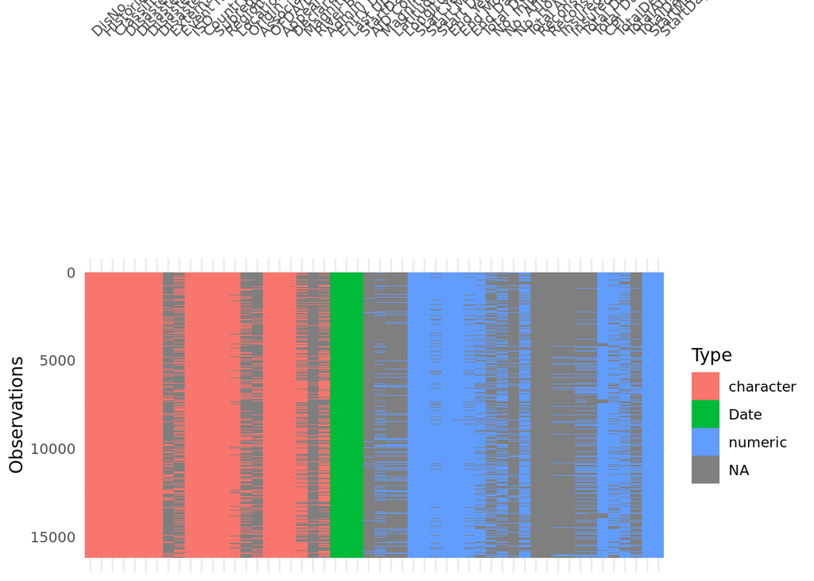

```r
vis_dat(disasters)
```

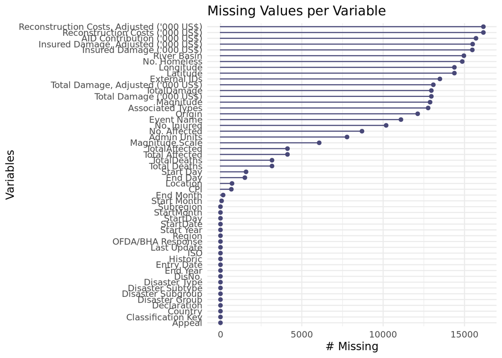

```r
gg_miss_var(disasters) +
ggtitle("Missing Values per Variable")
```

```r
disasters %>%
select(TotalDeaths, TotalAffected, TotalDamage, Latitude, Longitude) %>%
miss_var_summary()
```

```
## # A tibble: 5 × 3
##   variable      n_miss pct_miss
##   <chr>          <int>    <num>
## 1 Latitude       14379     88.8
## 2 Longitude      14379     88.8
## 3 TotalDamage    12962     80.0
## 4 TotalAffected   4119     25.4
## 5 TotalDeaths     3167     19.6
```

## 7.Preparing Data for Hotspot Mapping

Hotspot mapping requires valid geographic coordinates. We retain only rows with non-missing latitude and longitude.

```r
disasters_validated <- disasters %>%
mutate(
TotalDeaths   = if_else(TotalDeaths   < 0, NA_real_, TotalDeaths),
TotalAffected = if_else(TotalAffected < 0, NA_real_, TotalAffected),
TotalDamage   = if_else(TotalDamage   < 0, NA_real_, TotalDamage)
) %>%
mutate(Magnitude = if_else(Magnitude < 0, NA_real_, Magnitude)) %>%
mutate(
Latitude  = if_else(Latitude  > 90  | Latitude  < -90,  NA_real_, Latitude),
Longitude = if_else(Longitude > 180 | Longitude < -180, NA_real_, Longitude)
) %>%
filter(!is.na(`Start Year`))

glimpse(disasters_validated)
```

```
## Rows: 16,194
## Columns: 52
## $ DisNo.                                      <chr> "1999-9388-DJI", "1999-938…
## $ Historic                                    <chr> "No", "No", "No", "No", "N…
## $ `Classification Key`                        <chr> "nat-cli-dro-dro", "nat-cl…
## $ `Disaster Group`                            <chr> "Natural", "Natural", "Nat…
## $ `Disaster Subgroup`                         <chr> "Climatological", "Climato…
## $ `Disaster Type`                             <chr> "Drought", "Drought", "Dro…
## $ `Disaster Subtype`                          <chr> "Drought", "Drought", "Dro…
## $ `External IDs`                              <chr> NA, NA, NA, NA, NA, NA, NA…
## $ `Event Name`                                <chr> NA, NA, NA, NA, NA, NA, NA…
## $ ISO                                         <chr> "DJI", "SDN", "SOM", "AGO"…
## $ Country                                     <chr> "Djibouti", "Sudan", "Soma…
## $ Subregion                                   <chr> "Sub-Saharan Africa", "Nor…
## $ Region                                      <chr> "Africa", "Africa", "Afric…
```

[output cut: 39 more lines]

```r
cap_outliers <- function(x, lower = 0.01, upper = 0.99) {
qnt <- quantile(x, probs = c(lower, upper), na.rm = TRUE)
x[x < qnt[1]] <- qnt[1]
x[x > qnt[2]] <- qnt[2]
return(x)
}

disasters_clean <- disasters_validated %>%
mutate(
TotalDeaths_capped   = cap_outliers(TotalDeaths),
TotalAffected_capped = cap_outliers(TotalAffected),
TotalDamage_capped   = cap_outliers(TotalDamage)
)

glimpse(disasters_clean)
```

```
## Rows: 16,194
## Columns: 55
## $ DisNo.                                      <chr> "1999-9388-DJI", "1999-938…
## $ Historic                                    <chr> "No", "No", "No", "No", "N…
## $ `Classification Key`                        <chr> "nat-cli-dro-dro", "nat-cl…
## $ `Disaster Group`                            <chr> "Natural", "Natural", "Nat…
## $ `Disaster Subgroup`                         <chr> "Climatological", "Climato…
## $ `Disaster Type`                             <chr> "Drought", "Drought", "Dro…
## $ `Disaster Subtype`                          <chr> "Drought", "Drought", "Dro…
## $ `External IDs`                              <chr> NA, NA, NA, NA, NA, NA, NA…
## $ `Event Name`                                <chr> NA, NA, NA, NA, NA, NA, NA…
## $ ISO                                         <chr> "DJI", "SDN", "SOM", "AGO"…
## $ Country                                     <chr> "Djibouti", "Sudan", "Soma…
## $ Subregion                                   <chr> "Sub-Saharan Africa", "Nor…
## $ Region                                      <chr> "Africa", "Africa", "Afric…
```

[output cut: 42 more lines]

```r
disasters_hotspot <- disasters %>%
mutate(
Latitude  = if_else(Latitude == 0, NA_real_, Latitude),
Longitude = if_else(Longitude == 0, NA_real_, Longitude)
) %>%
filter(!is.na(Latitude), !is.na(Longitude)) %>%
mutate(
TotalDeaths   = if_else(is.na(TotalDeaths),   0, TotalDeaths),
TotalAffected = if_else(is.na(TotalAffected), 0, TotalAffected)
)

head(disasters_hotspot)
```

```
## # A tibble: 6 × 52
##   DisNo.      Historic `Classification Key` `Disaster Group` `Disaster Subgroup`
##   <chr>       <chr>    <chr>                <chr>            <chr>
## 1 2000-0653-… No       nat-geo-ear-gro      Natural          Geophysical
## 2 2001-0005-… No       nat-geo-ear-gro      Natural          Geophysical
## 3 2001-0299-… No       nat-hyd-flo-fla      Natural          Hydrological
## 4 2002-0033-… No       nat-geo-vol-ash      Natural          Geophysical
## 5 2002-0042-… No       nat-geo-ear-gro      Natural          Geophysical
## 6 2002-0545-… No       nat-geo-ear-gro      Natural          Geophysical
## # ℹ 47 more variables: `Disaster Type` <chr>, `Disaster Subtype` <chr>,
## #   `External IDs` <chr>, `Event Name` <chr>, ISO <chr>, Country <chr>,
## #   Subregion <chr>, Region <chr>, Location <chr>, Origin <chr>,
## #   `Associated Types` <chr>, `OFDA/BHA Response` <chr>, Appeal <chr>,
## #   Declaration <chr>, `AID Contribution ('000 US$)` <dbl>, Magnitude <dbl>,
## #   `Magnitude Scale` <chr>, Latitude <dbl>, Longitude <dbl>,
## #   `River Basin` <chr>, `Start Year` <dbl>, `Start Month` <dbl>, …
```

## 8.Hotspot Mapping Using Leaflet

An interactive world map is created to highlight significant disaster locations. Circle sizes are scaled using a logarithmic transformation of total deaths.

```r
pal <- colorFactor("Set1", domain = disasters_hotspot$`Disaster Type`)

radius_vec <- log10(disasters_hotspot$TotalDeaths + 1)
radius_min <- min(radius_vec, na.rm = TRUE)
radius_max <- max(radius_vec, na.rm = TRUE)

radius_scaled <- if (radius_max > radius_min) {
3 + 7 * (radius_vec - radius_min) / (radius_max - radius_min)
} else {
rep(5, length(radius_vec))
}

leaflet(disasters_hotspot) %>%
addProviderTiles("Esri.WorldGrayCanvas") %>%
addCircleMarkers(
lng = ~Longitude,
lat = ~Latitude,
radius = radius_scaled,
stroke = FALSE,
fillOpacity = 0.7,
color = ~pal(`Disaster Type`),
popup = ~paste0(
"<b>Country:</b> ", Country, "<br/>",
"<b>Disaster Group:</b> ", `Disaster Group`, "<br/>",
"<b>Disaster Type:</b> ", `Disaster Type`, "<br/>",
"<b>Total Deaths:</b> ", TotalDeaths, "<br/>",
"<b>Total Affected:</b> ", TotalAffected
),
clusterOptions = markerClusterOptions()
) %>%
addLegend("bottomright", pal = pal,
values = ~`Disaster Type`,
title = "Disaster Type")
```

[interactive chart not shown]

## 9.Constructing a Country-Level Vulnerability Index

To quantify vulnerability, we combine human and economic impact using a weighted index.

Weights used:

Component Weight Total deaths 0.5 Total affected 0.3 Total damage 0.2

```r
normalize_01 <- function(x) {
if (all(is.na(x))) return(rep(0, length(x)))
rng <- range(x, na.rm = TRUE)
if (rng[1] == rng[2]) return(rep(0.5, length(x)))
(x - rng[1]) / (rng[2] - rng[1])
}
country_scores <- disasters_clean %>%
group_by(Country, Region) %>%
summarise(
total_deaths   = sum(TotalDeaths_capped, na.rm = TRUE),
total_affected = sum(TotalAffected_capped, na.rm = TRUE),
total_damage   = sum(TotalDamage_capped, na.rm = TRUE),
.groups = "drop"
) %>%
mutate(
deaths_norm   = normalize_01(total_deaths),
affected_norm = normalize_01(total_affected),
damage_norm   = normalize_01(total_damage),
vulnerability_index =
0.5 * deaths_norm +
0.3 * affected_norm +
0.2 * damage_norm
) %>%
arrange(desc(vulnerability_index))

head(country_scores)
```

```
## # A tibble: 6 × 9
##   Country            Region total_deaths total_affected total_damage deaths_norm
##   <chr>              <chr>         <dbl>          <dbl>        <dbl>       <dbl>
## 1 China              Asia          43851     547404028.   427017674.       0.761
## 2 India              Asia          57621     277845023.   122987561        1
## 3 United States of … Ameri…        11815      26729880.  1008206360        0.205
## 4 Philippines        Asia          21090     197950842.    25078632.       0.366
## 5 Indonesia          Asia          23227      31589427.    23516517        0.403
## 6 Nigeria            Africa        23787      22639327.     5372922        0.413
## # ℹ 3 more variables: affected_norm <dbl>, damage_norm <dbl>,
## #   vulnerability_index <dbl>
```

## 10.Top 15 Most Vulnerable Countries

A comparative bar plot is generated using ggplot2.

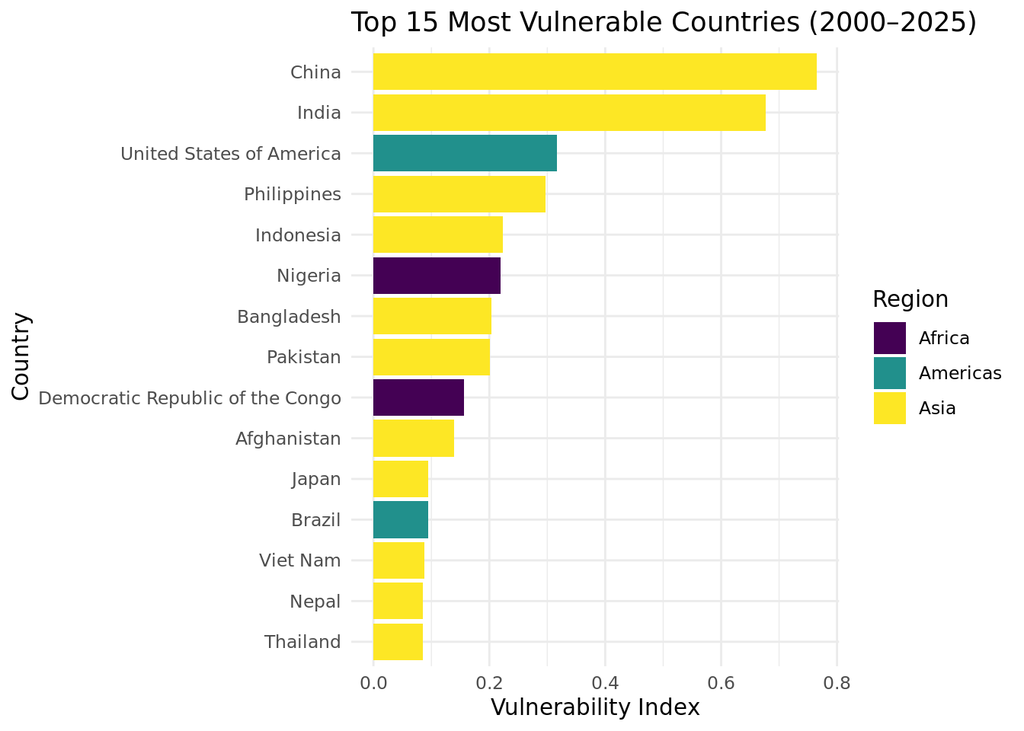

```r
top15 <- country_scores %>% slice(1:15)

ggplot(top15,
aes(x = reorder(Country, vulnerability_index),
y = vulnerability_index,
fill = Region)) +
geom_col() +
coord_flip() +
scale_fill_viridis_d() +
labs(
title = "Top 15 Most Vulnerable Countries (2000–2025)",
x = "Country",
y = "Vulnerability Index"
) +
theme_minimal()
```

## 11.Disaster Events by Region and period

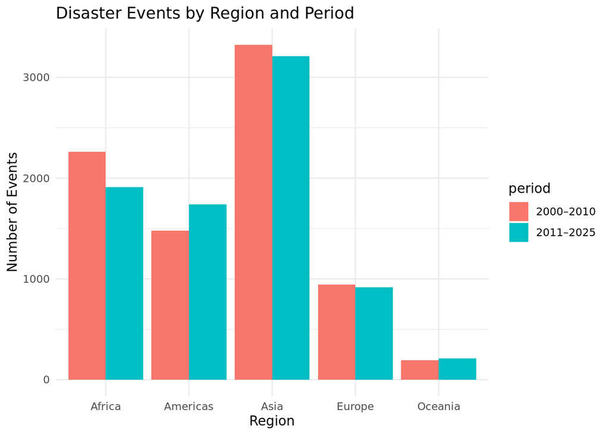

```r
disasters %>%
mutate(period = if_else(`Start Year` <= 2010, "2000–2010", "2011–2025")) %>%
group_by(period, Region) %>%
summarise(
events = n(),
deaths = sum(TotalDeaths, na.rm = TRUE),
affected = sum(TotalAffected, na.rm = TRUE),
.groups = "drop"
) %>%
ggplot(aes(x = Region, y = events, fill = period)) +
geom_col(position = "dodge") +
theme_minimal() +
labs(
title = "Disaster Events by Region and Period",
x = "Region",
y = "Number of Events"
)
```

## 12.Number of Disaster by type

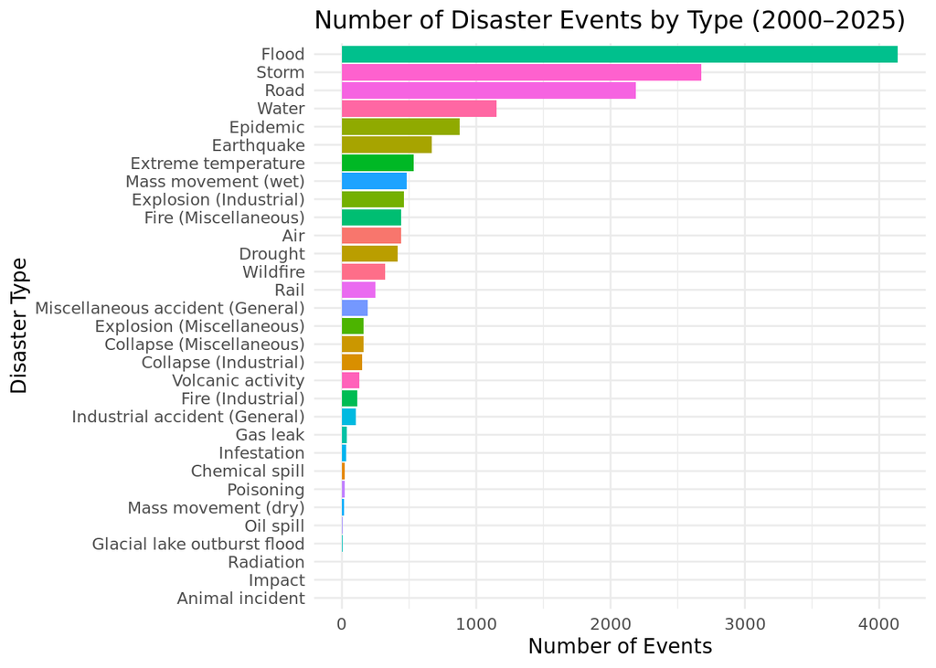

```r
disasters %>%
count(`Disaster Type`) %>%
ggplot(aes(x = reorder(`Disaster Type`, n), y = n, fill = `Disaster Type`)) +
geom_col() +
coord_flip() +
labs(
title = "Number of Disaster Events by Type (2000–2025)",
x = "Disaster Type",
y = "Number of Events"
) +
theme_minimal() +
theme(legend.position = "none")
```

## 13.Total Death distribution

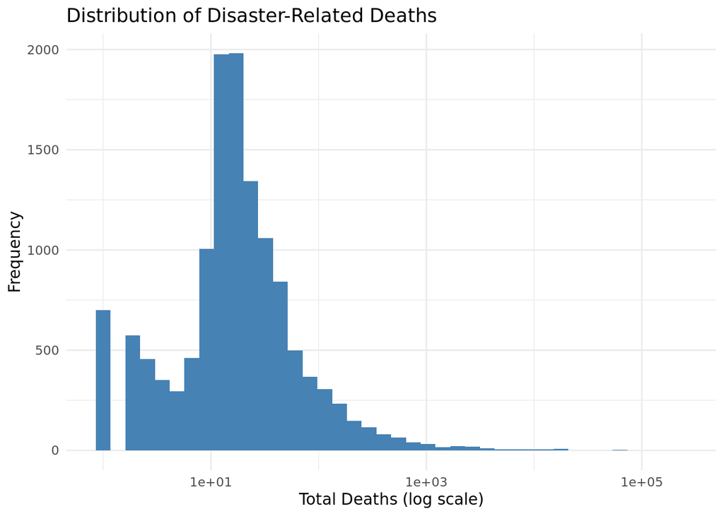

```r
disasters %>%
filter(!is.na(TotalDeaths), TotalDeaths > 0) %>%
ggplot(aes(x = TotalDeaths)) +
geom_histogram(bins = 40, fill = "steelblue") +
scale_x_log10() +
labs(
title = "Distribution of Disaster-Related Deaths",
x = "Total Deaths (log scale)",
y = "Frequency"
) +
theme_minimal()
```

## 14.Number of Events by year

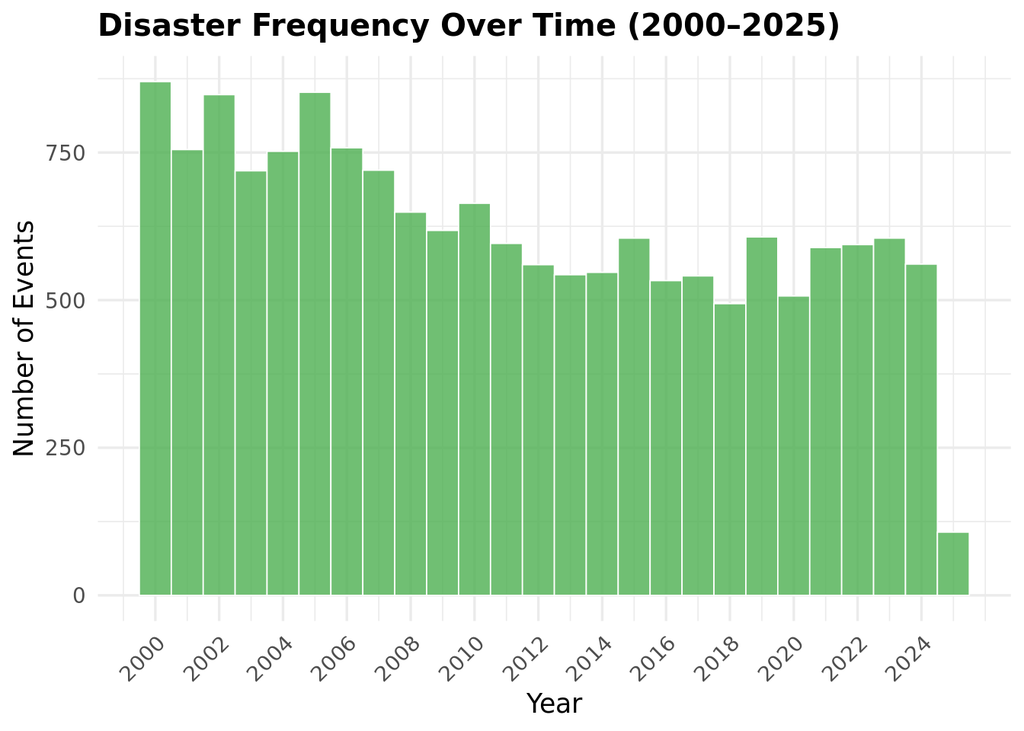

```r
disasters %>%
ggplot(aes(x = `Start Year`)) +
geom_histogram(
binwidth = 1,
fill = "#4CAF50",
alpha = 0.8,
color = "white",
linewidth = 0.3
) +
scale_x_continuous(
breaks = seq(min(disasters$`Start Year`, na.rm = TRUE),
max(disasters$`Start Year`, na.rm = TRUE),
by = 2)
) +
labs(
title = "Disaster Frequency Over Time (2000–2025)",
x = "Year",
y = "Number of Events"
) +
theme_minimal(base_size = 13) +
theme(
plot.title = element_text(face = "bold", size = 15),
axis.text.x = element_text(angle = 45, hjust = 1)
)
```

## 15. Conclusion

This project provided a comprehensive analysis of global disasters from 2000 to 2025 using R. Through systematic data cleaning, domain-based validation, outlier capping, geospatial hotspot mapping, and the construction of a vulnerability index, the study identified highly vulnerable countries and regions. The combination of statistical analysis and interactive visualisations demonstrates the usefulness of R for large-scale disaster analytics.